# Red Wine Quality Analysis

#### alcohol(sqrt) & quality

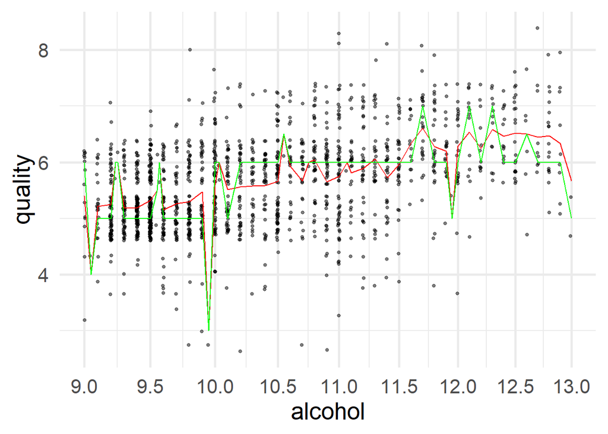

```r
ggplot(aes(x=alcohol, y=quality),data=df)+
  geom_point(alpha = 0.5, size = 1, position = 'jitter')+
  scale_x_continuous(trans="sqrt",
                     limits = c(9, 13),
                     breaks = seq(9, 13, 0.5))+
  scale_y_continuous() +
  geom_line(stat='summary', fun.y=mean, linetype=1, color='red')+
  geom_line(stat='summary', fun.y=quantile, fun.args=list(probs=.5),linetype=1, color='green')
```

#### alcohol & quality: correlation (0.4785317 >0.3)

```r
with(df, cor.test(alcohol, quality, method = "spearman"))
```

```
##
##  Spearman's rank correlation rho
##
## data:  alcohol and quality
## S = 355320000, p-value < 2.2e-16
## alternative hypothesis: true rho is not equal to 0
## sample estimates:
##       rho
## 0.4785317
```

```r
with(
  subset(df, alcohol>9, alcohol<13),
  cor.test(alcohol, quality, method = "spearman")
)
```

```
##
##  Spearman's rank correlation rho
##
## data:  alcohol and quality
## S = 323260000, p-value < 2.2e-16
## alternative hypothesis: true rho is not equal to 0
## sample estimates:
##       rho
## 0.4910647
```

### Explore the 3 variables significantly correlated with quality

3 chemicals are correlated with quality:

- volatile.acidity: negative
- sulphates: positive
- alcohol: positive

#### alcohol & sulphates

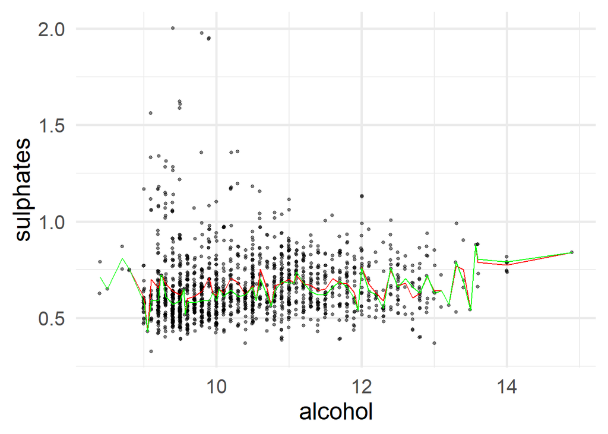

```r
ggplot(aes(x=alcohol, y=sulphates),data=df)+
  geom_point(alpha = 0.5, size = 1, position = 'jitter')+
  scale_y_continuous() +
  geom_line(stat='summary', fun.y=mean, linetype=1, color='red')+
  geom_line(stat='summary', fun.y=quantile, fun.args=list(probs=.5),linetype=1, color='green')
```

#### alcohol & sulphates: correlation (0.1356407)

```r
with(df, cor.test(sqrt(alcohol), log10(sulphates)))
```

```
##
##  Pearson's product-moment correlation
##
## data:  sqrt(alcohol) and log10(sulphates)
## t = 5.4711, df = 1597, p-value = 5.184e-08
## alternative hypothesis: true correlation is not equal to 0
## 95 percent confidence interval:
##  0.08719941 0.18344212
## sample estimates:
##       cor
## 0.1356407
```

#### alcohol, sulphates & quality

```r
#group df by alcohol

# add a new variable for grouping
df$alcohol.joint <-
  cut(df$alcohol, c(8.4,9.2,9.5,10,10.5,11,12,14.9))

# check the new variable
table(df$alcohol.joint, useNA = 'ifany')
```

```
##
## (8.4,9.2] (9.2,9.5]  (9.5,10] (10,10.5] (10.5,11]   (11,12] (12,14.9]
##       131       303       311       236       208       267       141
##      <NA>
##         2
```

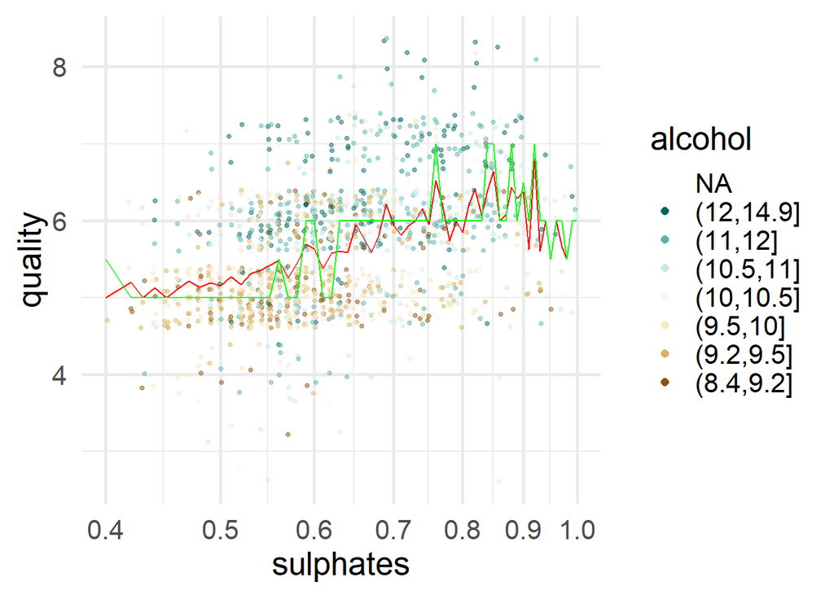

```r
ggplot(aes(x=sulphates, y=quality, color = alcohol.joint),data=df)+
  geom_point(alpha = 0.5, size = 1, position = 'jitter')+
  scale_color_brewer(type = 'div',
                     guide = guide_legend(title = "alcohol",
                                          reverse = TRUE,
                                          override.aes = list(alpha = 1, size = 2)))+
  scale_x_continuous(trans='log10',
                     limits = c(0.4, 1.0),
                     breaks = seq(0.4, 1.0, 0.1))+
  geom_line(stat='summary', fun.y=mean, linetype=1, color='red')+
  geom_line(stat='summary', fun.y=quantile, fun.args=list(probs=.5),linetype=1, color='green')
```

#### alcohol & volatile.acidity

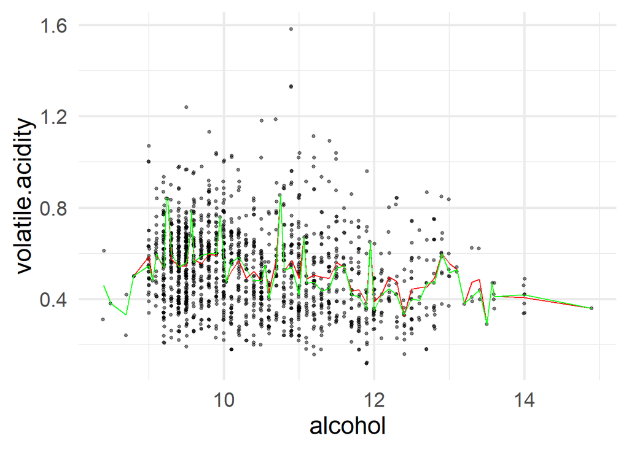

```r
ggplot(aes(x=alcohol, y=volatile.acidity),data=df)+
  geom_point(alpha = 0.5, size = 1, position = 'jitter')+
  scale_y_continuous() +
  geom_line(stat='summary', fun.y=mean, linetype=1, color='red')+
  geom_line(stat='summary', fun.y=quantile, fun.args=list(probs=.5),linetype=1, color='green')
```

#### alcohol & volatile.acidity: correlation (-0.2019826 )

```r
with(df, cor.test(sqrt(alcohol), volatile.acidity))
```

```
##
##  Pearson's product-moment correlation
##
## data:  sqrt(alcohol) and volatile.acidity
## t = -8.2416, df = 1597, p-value = 3.502e-16
## alternative hypothesis: true correlation is not equal to 0
## 95 percent confidence interval:
##  -0.2485428 -0.1544911
## sample estimates:
##        cor
## -0.2019826
```

#### alcohol, volatile.acidity & quality

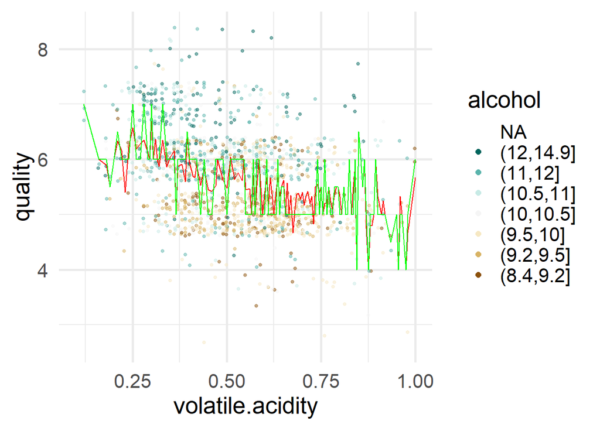

```r
ggplot(aes(x=volatile.acidity, y=quality, color = alcohol.joint),data=df)+
  geom_point(alpha = 0.5, size = 1, position = 'jitter')+
  scale_color_brewer(type = 'div',
                     guide = guide_legend(title = "alcohol",
                                          reverse = TRUE,
                                          override.aes = list(alpha = 1, size = 2)))+
  scale_x_continuous(limits = c(0.1,1))+
  geom_line(stat='summary', fun.y=mean, linetype=1, color='red')+
  geom_line(stat='summary', fun.y=quantile, fun.args=list(probs=.5),linetype=1, color='green')
```

#### Regression

```r
m1 <- lm(I(quality) ~ I(sqrt(alcohol)), data = df)
m2 <- update(m1, ~ . + log10(sulphates))
m3 <- update(m2, ~ . + volatile.acidity)

mtable(m1, m2, m3)
```

```
##
## Calls:
## m1: lm(formula = I(quality) ~ I(sqrt(alcohol)), data = df)
## m2: lm(formula = I(quality) ~ I(sqrt(alcohol)) + log10(sulphates),
##     data = df)
## m3: lm(formula = I(quality) ~ I(sqrt(alcohol)) + log10(sulphates) +
##     volatile.acidity, data = df)
##
## ==============================================================
##                          m1            m2            m3
## --------------------------------------------------------------
##   (Intercept)          -2.024***     -1.082**       0.089
##                        (0.354)       (0.349)       (0.349)
##   I(sqrt(alcohol))      2.376***      2.208***      1.998***
##                        (0.110)       (0.106)       (0.103)
##   log10(sulphates)                    2.067***      1.474***
##                                      (0.177)       (0.177)
##   volatile.acidity                                 -1.156***
##                                                    (0.097)
## --------------------------------------------------------------
##   R-squared             0.227         0.288         0.346
##   adj. R-squared        0.227         0.287         0.345
##   sigma                 0.710         0.682         0.654
##   F                   469.933       322.775       281.289
##   p                     0.000         0.000         0.000
##   Log-likelihood    -1720.412     -1655.071     -1587.119
##   Deviance            805.221       742.029       681.568
##   AIC                3446.824      3318.141      3184.237
##   BIC                3462.955      3339.650      3211.123
##   N                  1599          1599          1599
## ==============================================================
```

### pH, fixed.acidity & density

#### fixed.acidity & density

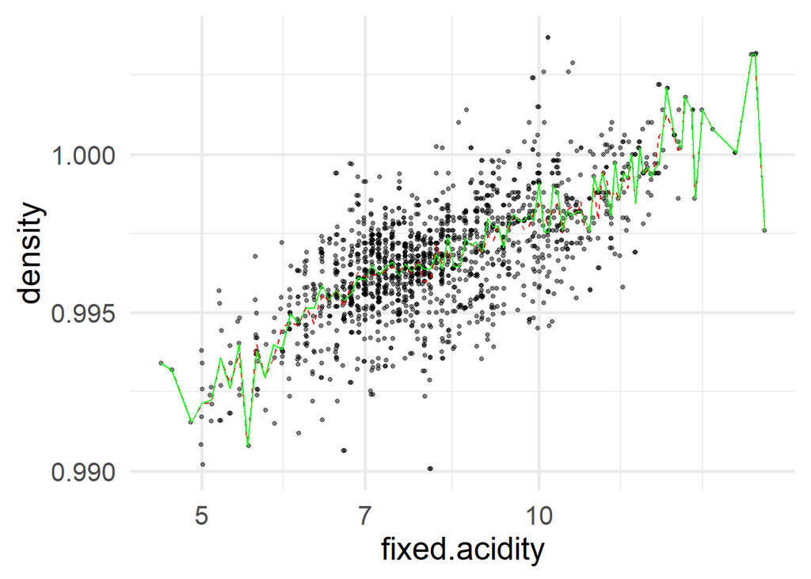

```r
ggplot(aes(x=fixed.acidity, y=density),data=df)+
  geom_point(alpha = 0.5, size = 1, position = 'jitter')+
  scale_x_continuous(trans="log10")+
  scale_y_continuous() +
  geom_line(stat='summary', fun.y=mean, linetype=2, color='red')+
  geom_line(stat='summary', fun.y=quantile, fun.args=list(probs=.5),linetype=1, color='green')
```

#### fixed.acidity & density: Correlation (0.6680473 > 0.5)

```r
with(df,cor.test(fixed.acidity, density))
```

```
##
##  Pearson's product-moment correlation
##
## data:  fixed.acidity and density
## t = 35.877, df = 1597, p-value < 2.2e-16
## alternative hypothesis: true correlation is not equal to 0
## 95 percent confidence interval:
##  0.6399847 0.6943302
## sample estimates:
##       cor
## 0.6680473
```

#### fixed.acidity & pH

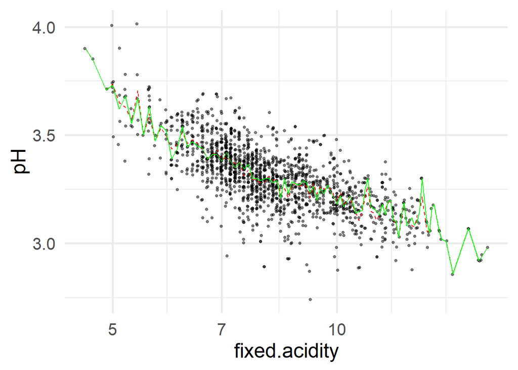

```r
ggplot(aes(x=fixed.acidity, y=pH),data=df)+
  geom_point(alpha = 0.5, size = 1, position = 'jitter')+
  scale_x_continuous(trans="log10")+
  scale_y_continuous() +
  geom_line(stat='summary', fun.y=mean, linetype=2, color='red')+
  geom_line(stat='summary', fun.y=quantile, fun.args=list(probs=.5),linetype=1, color='green')
```

#### fixed.acidity & pH: Correlation (-0.6829782 > 0.5)

```r
with(df,cor.test(fixed.acidity, pH))
```

```
##
##  Pearson's product-moment correlation
##
## data:  fixed.acidity and pH
## t = -37.366, df = 1597, p-value < 2.2e-16
## alternative hypothesis: true correlation is not equal to 0
## 95 percent confidence interval:
##  -0.7082857 -0.6559174
## sample estimates:
##        cor
## -0.6829782
```

#### density & pH

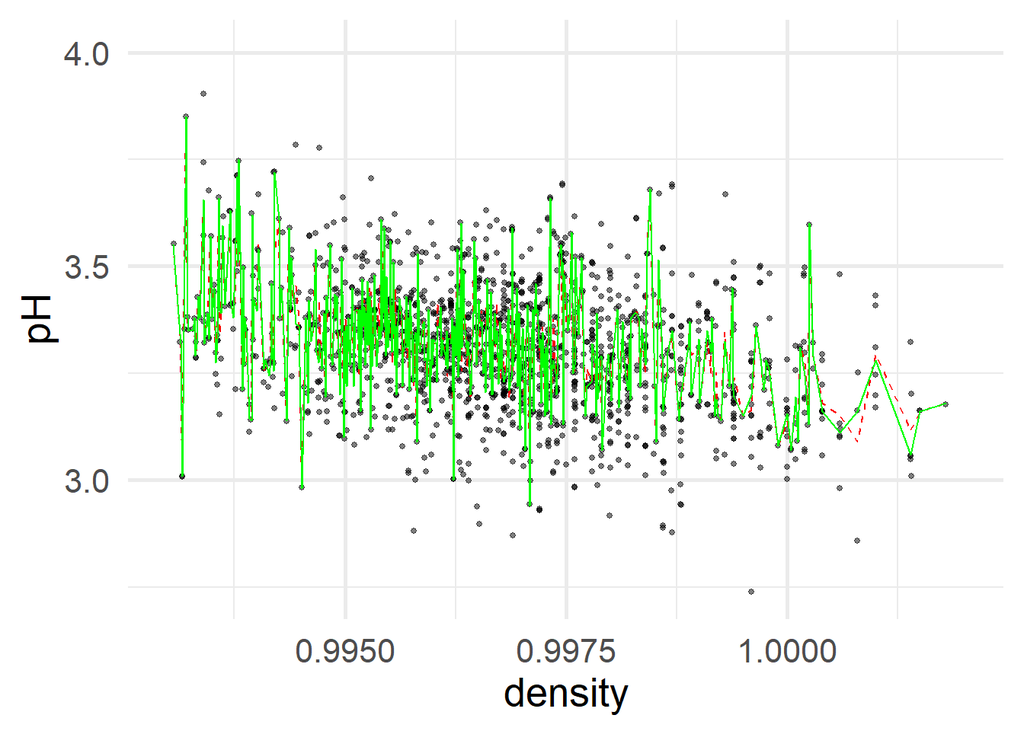

```r
ggplot(aes(x=density, y=pH),data=df)+
  geom_point(alpha = 0.5, size = 1, position = 'jitter')+
  scale_x_continuous(limits = c(0.993, 1.002))+
  geom_line(stat='summary', fun.y=mean, linetype=2, color='red')+
  geom_line(stat='summary', fun.y=quantile, fun.args=list(probs=.5),linetype=1, color='green')
```

#### density & pH: Correlation (-0.3416993 < -0.3)

```r
with(df,cor.test(density, pH))
```

```
##
##  Pearson's product-moment correlation
##
## data:  density and pH
## t = -14.53, df = 1597, p-value < 2.2e-16
## alternative hypothesis: true correlation is not equal to 0
## 95 percent confidence interval:
##  -0.3842835 -0.2976642
## sample estimates:
##        cor
## -0.3416993
```

#### pH, fixed.acidity & density: plot1 (grouping fixed acidity)

```r
summary(df$fixed.acidity)
```

```
##    Min. 1st Qu.  Median    Mean 3rd Qu.    Max.
##    4.60    7.10    7.90    8.32    9.20   15.90
```

```r
#group df by fixed.acidity

# add a new variable for grouping
df$fixed.acidity.joint <-
  cut(df$fixed.acidity, c(4.60, 7.10, 7.90, 9.20, 15.90))

# check the new variable
table(df$fixed.acidity.joint, useNA = 'ifany')
```

```
##
##  (4.6,7.1]  (7.1,7.9]  (7.9,9.2] (9.2,15.9]       <NA>
##        418        397        387        396          1
```

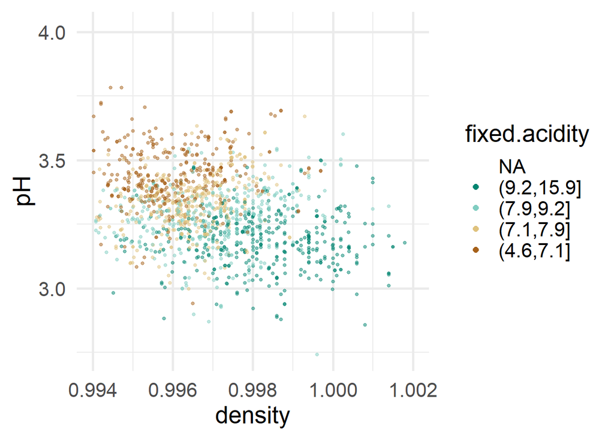

```r
# Without mean/ median lines
ggplot(aes(x=density, y=pH, color = fixed.acidity.joint),data=df)+
  geom_point(alpha = 0.5, size = 1, position = 'jitter')+
  scale_color_brewer(type = 'div',
                     guide = guide_legend(title = "fixed.acidity",
                                          reverse = TRUE,
                                          override.aes = list(alpha = 1, size = 2)))+
  scale_x_continuous(limits = c(0.994, 1.002))
```

Fixed Acidity rises, when density increases and pH decreases. Fixed Acidity drops, when density decreases and pH increases.

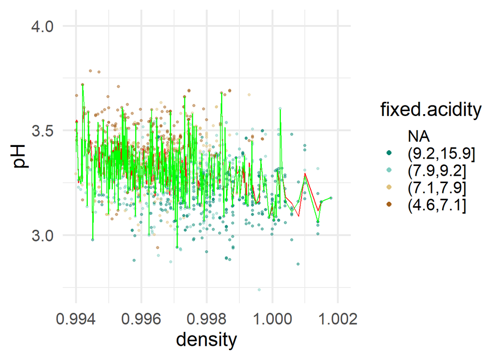

```r
# With mean/ median lines
ggplot(aes(x=density, y=pH, color = fixed.acidity.joint),data=df)+
  geom_point(alpha = 0.5, size = 1, position = 'jitter')+
  scale_color_brewer(type = 'div',
                     guide = guide_legend(title = "fixed.acidity",
                                          reverse = TRUE,
                                          override.aes = list(alpha = 1, size = 2)))+
  scale_x_continuous(limits = c(0.994, 1.002))+
  geom_line(stat='summary', fun.y=mean, linetype=1, color='red')+
  geom_line(stat='summary', fun.y=quantile, fun.args=list(probs=.5),linetype=1, color='green')
```

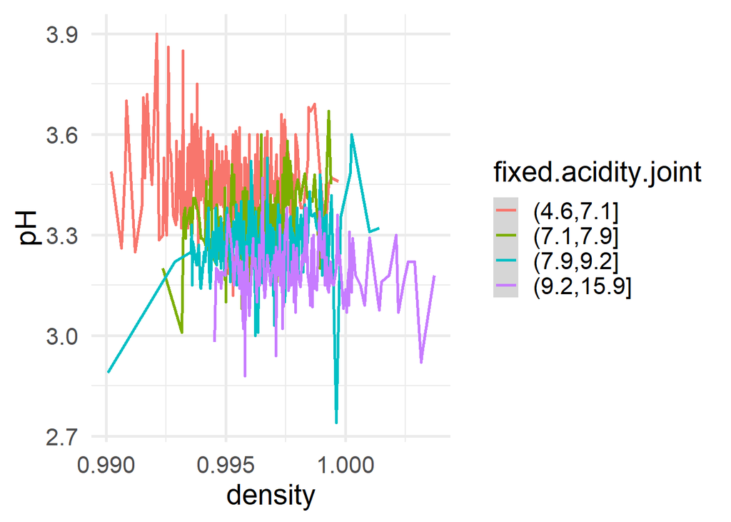

```r
ggplot(
  aes(x=density, y=pH), data=subset(df, !is.na(fixed.acidity.joint))
)+
  geom_smooth(
    aes(color=fixed.acidity.joint),
    stat='summary',
    fun.y=mean
  )
```

### pH, fixed.acidity & density: plot2 (grouping pH Values)

```r
summary(df$pH)
```

```
##    Min. 1st Qu.  Median    Mean 3rd Qu.    Max.
##   2.740   3.210   3.310   3.311   3.400   4.010
```

```r
#group df by fixed.acidity

# add a new variable for grouping
df$ph.joint <-
  cut(df$pH, c(2.740, 3.210, 3.310, 3.400, 4.010))

# check the new variable
table(df$ph.joint, useNA = 'ifany')
```

```
##
## (2.74,3.21] (3.21,3.31]  (3.31,3.4]  (3.4,4.01]        <NA>
##         423         398         390         387           1
```

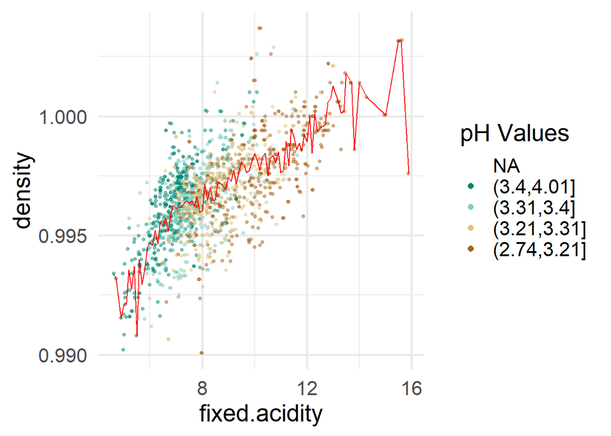

```r
# Without mean/ median lines
ggplot(aes(x=fixed.acidity, y=density, color = ph.joint),data=df)+
  geom_point(alpha = 0.5, size = 1, position = 'jitter')+
  scale_color_brewer(type = 'div',
                     guide = guide_legend(title = "pH Values",
                                          reverse = TRUE,
                                          override.aes = list(alpha = 1, size = 2)))+
  scale_x_continuous() +
  geom_line(stat='summary', fun.y=mean, linetype=1, color='red')
```

### density, alcohol, quality

#### density & alcohol

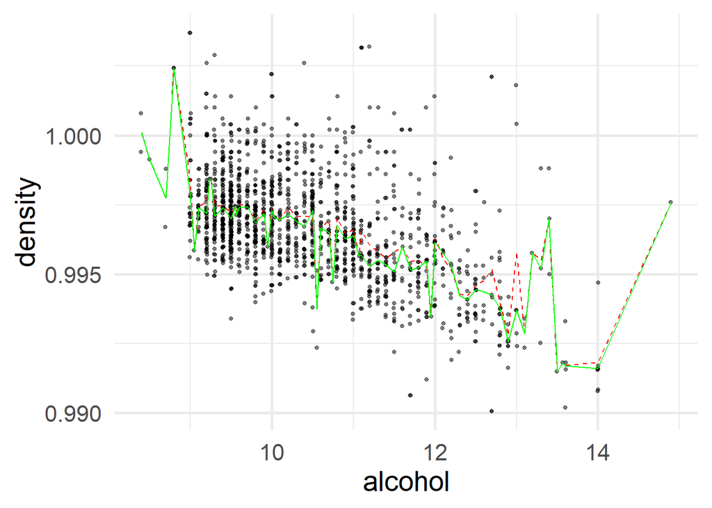

```r
ggplot(aes(x=alcohol, y=density),data=df)+
  geom_point(alpha = 0.5, size = 1, position = 'jitter')+
  scale_x_continuous()+
  geom_line(stat='summary', fun.y=mean, linetype=2, color='red')+
  geom_line(stat='summary', fun.y=quantile, fun.args=list(probs=.5),linetype=1, color='green')
```

#### density & alcohol: Correlation (-0.4961798 < -0.3)

```r
with(df,cor.test(density, alcohol))
```

```
##
##  Pearson's product-moment correlation
##
## data:  density and alcohol
## t = -22.838, df = 1597, p-value < 2.2e-16
## alternative hypothesis: true correlation is not equal to 0
## 95 percent confidence interval:
##  -0.5322547 -0.4583061
## sample estimates:
##        cor
## -0.4961798
```

#### density, alcohol, quality

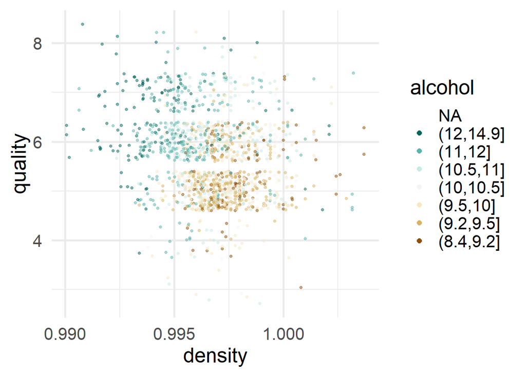

```r
# With mean/ median lines
ggplot(aes(x=density, y=quality, color = alcohol.joint),data=df)+
  geom_point(alpha = 0.5, size = 1, position = 'jitter')+
  scale_color_brewer(type = 'div',
                     guide = guide_legend(title = "alcohol",
                                          reverse = TRUE,
                                          override.aes = list(alpha = 1, size = 2)))+
  scale_x_continuous()
```

```r
#group df by alcohol

df$alcohol.half <-
  cut(df$alcohol,
      c(8.40, 10.20, 14.90))

table(df$alcohol.half,
      useNA = 'ifany')
```

```
##
##  (8.4,10.2] (10.2,14.9]        <NA>
##         840         757           2
```

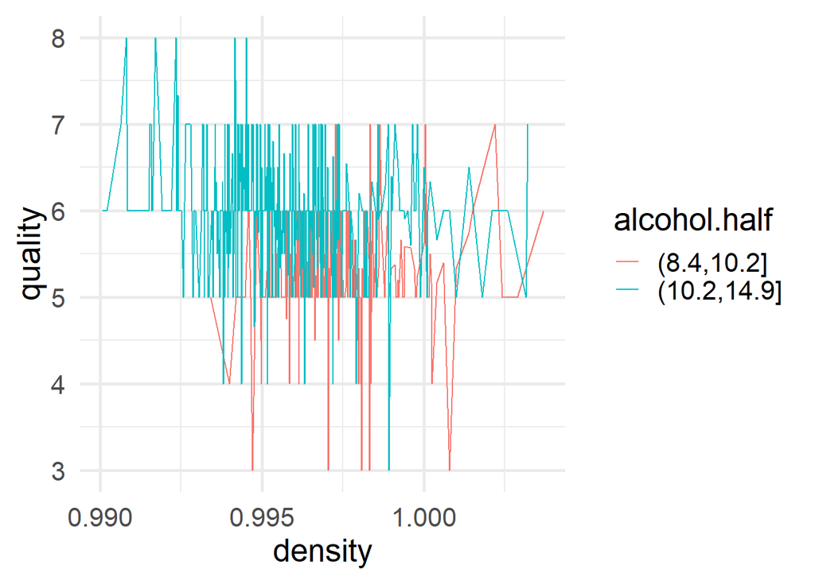

```r
ggplot(aes(density, quality), data=subset(df, !is.na(alcohol.half)))+
  geom_line(aes(color=alcohol.half),
            stat='summary',
            fun.y=mean)
```

#### density & alcohol interaction vs quality: Correlation (0.4772388 > 0.3)

```r
with(df,cor.test(density*alcohol, quality))
```

```
##
##  Pearson's product-moment correlation
##
## data:  density * alcohol and quality
## t = 21.703, df = 1597, p-value < 2.2e-16
## alternative hypothesis: true correlation is not equal to 0
## 95 percent confidence interval:
##  0.4384757 0.5142297
## sample estimates:
##       cor
## 0.4772388
```

## Final Plots and Summary

3 chemicals are correlated with quality:

- volatile.acidity: negative
- sulphates: positive
- alcohol: positive

### The relationship between alcohol, sulphates and quality

#### Plot:

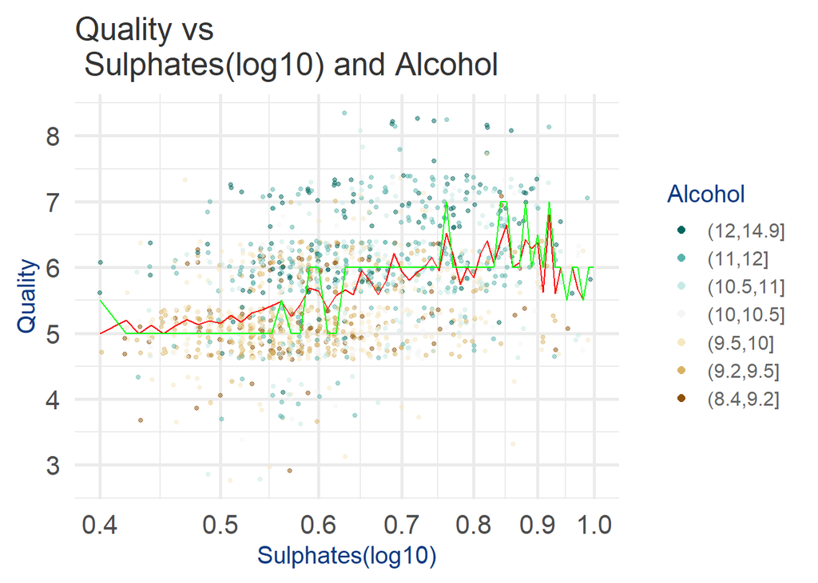

```r
ggplot(aes(x=sulphates, y=quality, color = alcohol.joint),data=subset(df, !is.na(alcohol.joint)))+
  geom_point(alpha = 0.5, size = 1, position = 'jitter')+
  scale_color_brewer(type = 'div',
                     guide = guide_legend(title = "Alcohol",
                                          reverse = TRUE,
                                          override.aes = list(alpha = 1, size = 2)))+
  scale_x_continuous(trans='log10',
                     limits = c(0.4, 1.0),
                     breaks = seq(0.4, 1.0, 0.1))+
  scale_y_continuous(breaks = seq(3,8,1))+
  geom_line(stat='summary', fun.y=mean, linetype=1, color='red')+
  geom_line(stat='summary', fun.y=quantile, fun.args=list(probs=.5),linetype=1, color='green')+
  ggtitle('Quality vs\n Sulphates(log10) and Alcohol')+
  xlab("Sulphates(log10)") +
  ylab("Quality")+
  theme(plot.title = element_text(size = 20, colour = "#333333"),
        axis.title.x = element_text(size = 15, colour = "#0e3b82"),
        axis.title.y = element_text(size = 15, colour = "#0e3b82"),
        legend.title = element_text(size = 15, colour = "#0e3b82"),
        legend.text = element_text(size = 12, colour = "#666666"))
```

#### Findings:

- Alcohol and quality are positively correlated.
- Sulphates and quality are positively correlated.

### The relationship between alcohol, volatile acidity and quality

#### Plot:

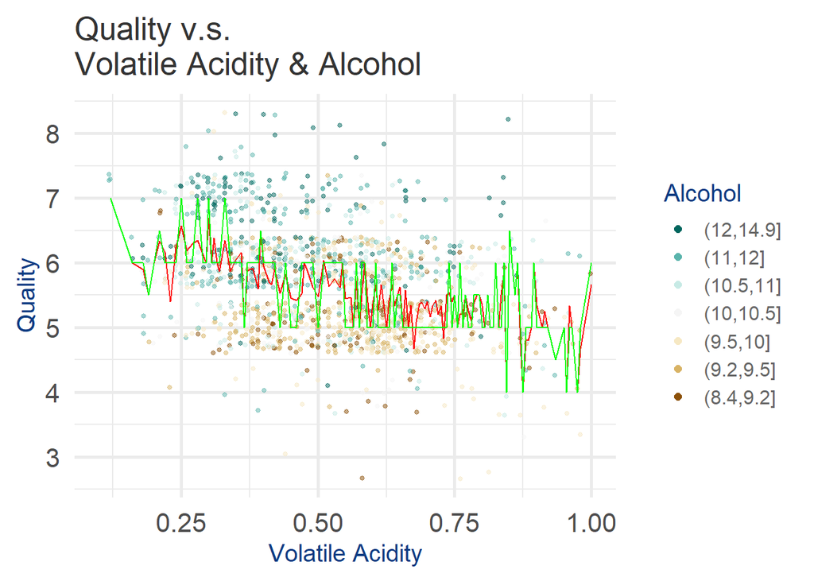

```r
ggplot(aes(x=volatile.acidity, y=quality, color = alcohol.joint),data=subset(df, !is.na(alcohol.joint)))+
  geom_point(alpha = 0.5, size = 1, position = 'jitter')+
  scale_color_brewer(type = 'div',
                     guide = guide_legend(title = "Alcohol",
                                          reverse = TRUE,
                                          override.aes = list(alpha = 1, size = 2)))+
  scale_x_continuous(limits = c(0.1 ,1))+
  scale_y_continuous(breaks = seq(3,8,1))+
  geom_line(stat='summary', fun.y=mean, linetype=1, color='red')+
  geom_line(stat='summary', fun.y=quantile, fun.args=list(probs=.5),linetype=1, color='green')+
  ggtitle('Quality v.s.\nVolatile Acidity & Alcohol')+
  xlab("Volatile Acidity") +
  ylab("Quality")+
  theme(plot.title = element_text(size = 20, colour = "#333333"),
        axis.title.x = element_text(size = 15, colour = "#0e3b82"),
        axis.title.y = element_text(size = 15, colour = "#0e3b82"),
        legend.title = element_text(size = 15, colour = "#0e3b82"),
        legend.text = element_text(size = 12, colour = "#666666"))
```

#### Findings:

- Alcohol and quality are positively correlated.
- Volatile acidity and quality are negatively correlated.

### PH, Fixed Acidity & Density

#### Plot:

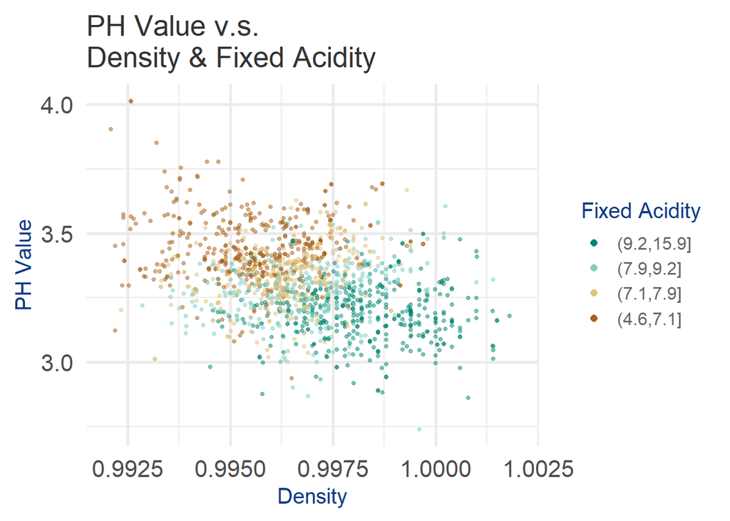

```r
ggplot(aes(x=density, y=pH, color = fixed.acidity.joint),data=subset(df, !is.na(fixed.acidity.joint)))+
  geom_point(alpha = 0.5, size = 1, position = 'jitter')+
  scale_color_brewer(type = 'div',
                     guide = guide_legend(title = "Fixed Acidity",
                                          reverse = TRUE,
                                          override.aes = list(alpha = 1, size = 2)))+
  scale_x_continuous(limits = c(0.992, 1.002))+
  ggtitle('PH Value v.s.\nDensity & Fixed Acidity')+
  xlab("Density") +
  ylab("PH Value")+
  theme(plot.title = element_text(size = 20, colour = "#333333"),
        axis.title.x = element_text(size = 15, colour = "#0e3b82"),
        axis.title.y = element_text(size = 15, colour = "#0e3b82"),
        legend.title = element_text(size = 15, colour = "#0e3b82"),
        legend.text = element_text(size = 12, colour = "#666666"))
```

#### Findings:

- Density and pH values are negatively correlated.
- Fixed acidity and pH values are negatively correlated.
- Fixed acidity and density values are positively correlated.

## Reflection

### Difficulties

There are too many variables. It takes very long time to explore the relationship between each 2 chemicals and the quality score.

Some of the chemicals are at least moderately correlated with others.

### Additional data and analyses

The quality scores are mainly between 5-6, and some are 7. Besides, none of the wines were scored 0-2 and 9-10. A 5-point scale would be better for scoring.

Besides, it would be helpful to ask experts to score the acidity and sweetness after tasting (e.g 1-Not sweet at all ~ 5-Too sweet).